# EP07-respuesta-equipo-4

2025-04-28

# Actividades:

En el trabajo de título de una estudiante del DIINF se reportan tiempos de ejecución (en milisegundos) y la cercanía con la solución óptima (en por ciento) de la mejor solución encontrada con tres versiones de un algoritmo genético para resolver instancias del problema del vendedor viajero disponibles en repositorios públicos. Ahora debe enfrentar el análisis de estos datos, por que está solicitando ayuda de las y los estudiantes de Estadística Inferencial.

En el contexto de este estudio, realizaremos las siguientes actividades:

Copiar los enunciados de las preguntas asignadas como comentarios de un script R. Obtener los datos, disponibles en el archivo “EP07 Datos.csv”, desde el directorio compartido correspondiente. Familiarizarse con los datos entregados y obtener las muestras indicadas. Enunciar las hipótesis nula y alternativa que permitan responder las preguntas planteadas. Argumentar o escribir código R para verificar que no se cumplen las condiciones para pruebas paramétricas con validez para el caso en estudio. Adaptar las hipótesis a contrastar de acuerdo al método solicitado en cada caso. Escribir código R para realizar los análisis estadísticos para datos problemáticos solicitados. Redactar la respuesta a la pregunta planteada en base a los resultados del análisis realizado. Antes de que venza el plazo para esta actividad (próximo miércoles por la noche), cada equipo debe subir el script realizado al correspondiente directorio compartido con el nombre “EP07-respuesta-equipo-i”, donde i es el número del equipo asignada. No identificar a los integrantes en la respuesta, para asegurar un proceso de revisión ciego. Si hay conflictos en el equipo respecto del trabajo realizado, estos deben ser comunicados vía correo electrónico al profesor.

```r
#-----------------------------------------------------------------------------------------------------------------------------
# Leer los datos
dato <- read.csv("EP07 Datos.csv") # ESTÁ EN FORMATO AMERICANO
#-----------------------------------------------------------------------------------------------------------------------------
# OBTENCION DE DATOS Y FILTRO
#m2 <- dato |> filter(area == "Biología")|> arrange(desc(tiempo))

alfa <- 0.05
```

# Pregunta 1:

Observando los datos, la memorista sospecha que hay diferencias significativas en el tiempo de ejecución entre las versiones B y C del algoritmo cuando las instancias tienen 65 o más nodos. ¿Los datos respaldan la intuición de la memorista? Para responder, filtren los datos para tener las instancias con 65 o más nodos y seleccionen las columnas de los tiempos de ejecución de las versiones B y C en formato ancho. Usando como semilla el valor 73, obtenga muestras aleatorias independientes de 24 tiempos registrados por la versión B y 20 tiempos registrados por la versión C del algoritmo. Realicen un análisis estadístico pertinente (enunciar hipótesis, revisar condiciones, seleccionar pruebas ómnibus y post-hoc según corresponda) para responder la pregunta planteada, utilizando pruebas no paramétricas de ser necesario.

**Hipótesis:**

```r
#----------------------------------------------------------------------------------
# NIVEL DE SIGNIFICANCIA:
alfa <- 0.05
#----------------------------------------------------------------------------------
ej_1 <- dato |> filter(n.nodos >= 65) |> select(tiempo.B, tiempo.C) |>
  sample_n(24, replace = FALSE, set.seed(73)) |>
  mutate(tiempo.B = as.numeric(tiempo.B), tiempo.C = as.numeric(tiempo.C))

# pasar a formato largo
ej_1_largo <- ej_1 |>
  pivot_longer(cols = everything(), names_to = "Version", values_to = "Tiempo") |>
  mutate(Instancia = rep(1:24, each = 2))
#----------------------------------------------------------------------------------
# VERIFICACIÓN DE LA NORMALIDAD
shapiro.test(ej_1$tiempo.B)
```

```
##
##  Shapiro-Wilk normality test
##
## data:  ej_1$tiempo.B
## W = 0.91487, p-value = 0.04505
```

```r
shapiro.test(ej_1$tiempo.C)
```

```
##
##  Shapiro-Wilk normality test
##
## data:  ej_1$tiempo.C
## W = 0.91501, p-value = 0.04535
```

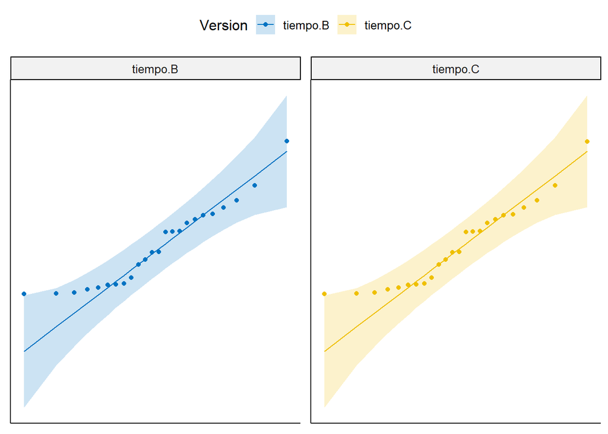

```r
#----------------------------------------------------------------------------------
#GRAFICO Q-Q
g <- ggqqplot(ej_1_largo, x = "Tiempo", color = "Version", palette = "jco") +
     facet_wrap(~ Version, scales = "free") +
     rremove("x.ticks") + rremove("x.text") +
     rremove("y.ticks") + rremove("y.text") +
     rremove("axis.title")

g
```

Como es posible observar, los valores p obtenidos 0.04505 y 0.04535 resultan ser menores al nivel de significancia 0.05 lo que indica que **no** se cumple la condición de normalidad para las dos muestras. Por lo que es necesario realizar una prueba no paramétrica..

**Análisis de prueba no parametrica correspondiente:**  
Tras el filtrado de información solicitado, es momento de evaluar que tipo de prueba que se va a utilizar para responder a la pregunta.

```r
#PRUEBA DE WILCOXON
wilcox.test(ej_1$tiempo.B, ej_1$tiempo.C, paired = FALSE, alternative = "two.sided", conf.int = TRUE)
```

```
##
##  Wilcoxon rank sum exact test
##
## data:  ej_1$tiempo.B and ej_1$tiempo.C
## W = 448, p-value = 0.0007186
## alternative hypothesis: true location shift is not equal to 0
## 95 percent confidence interval:
##   340180 1259431
## sample estimates:
## difference in location
##                 754056
```

# Pregunta 2

La memorista también sospecha que, al comparar las mismas instancias de iguales características, las mejores soluciones encontradas por las versiones A y B tienen rendimientos distintos. ¿Estará en lo cierto? Para responder, filtren los datos para tener las instancias con 65 o más nodos y seleccionen las columnas con el mejor rendimiento de las versiones A y B en formato ancho. Usando como semilla el valor 13, obtengan una muestra aleatoria de 22 instancias. Realicen un análisis estadístico pertinente (enunciar hipótesis, revisar condiciones, seleccionar pruebas ómnibus y post-hoc según corresponda) para responder la pregunta planteada, utilizando pruebas no paramétricas de ser necesario.

```r
ej_2 <- dato |> filter(n.nodos >= 65) |> select(mejor.A, mejor.B) |>
  sample_n(22, replace = FALSE, set.seed(13)) |>
  mutate(mejor.A = as.numeric(mejor.A), mejor.B = as.numeric(mejor.B))

# VERIFICACIÓN DE LA NORMALIDAD

shapiro.test(ej_2$mejor.A)
```

```
##
##  Shapiro-Wilk normality test
##
## data:  ej_2$mejor.A
## W = 0.87621, p-value = 0.01024
```

```r
shapiro.test(ej_2$mejor.B)
```

```
##
##  Shapiro-Wilk normality test
##
## data:  ej_2$mejor.B
## W = 0.90382, p-value = 0.03547
```

# Pregunta 3

La memorista sospecha que hay diferencias significativas en el tiempo de ejecución entre las versiones del algoritmo cuando las instancias de prueba tienen 50 o más nodos. ¿Los datos respaldan la intuición de la memorista? Para responder, filtren los datos para tener las instancias con 50 o más nodos y seleccionen las columnas con los tiempos de ejecución registrados (en formato ancho). Usando como semilla el valor 31, obtengan muestras aleatorias independientes de 15, 14 y 13 tiempos registrados por las versiones A, B y C, respectivamente. Realicen un análisis estadístico pertinente (enunciar hipótesis, revisar condiciones, seleccionar pruebas ómnibus y post-hoc según corresponda) para responder la pregunta planteada, utilizando pruebas no paramétricas de ser necesario.

# Pregunta 4

La memorista también sospecha que, al comparar las mismas instancias con iguales características, las mejores soluciones encontradas por las diferentes versiones del algoritmo tienen rendimientos distintos. ¿Estará en lo cierto? Para responder, filtren los datos para tener las instancias con 50 o más nodos y seleccionen las columnas con los mejores rendimientos registrados. Usando como semilla el valor 73, obtengan una muestra aleatoria de 22 instancias. Lleven los datos a formato largo y utilicen una prueba no paramétrica apropiada para analizar los datos obtenidos. Realicen un análisis estadístico pertinente (enunciar hipótesis, revisar condiciones, seleccionar pruebas ómnibus y post-hoc según corresponda) para responder la pregunta planteada, utilizando pruebas no paramétricas de ser necesario.

**Hipótesis:**

- H0: Las mejores soluciones encontradas por las diferentes versiones del algoritmo tienen rendimientos **iguales**.
- HA: Las mejores soluciones encontradas por las diferentes versiones del algoritmo tienen al menos un rendimientos **distinto**.

```r
#----------------------------------------------------------------------------------
# NIVEL DE SIGNIFICANCIA:
alfa <- 0.01
#----------------------------------------------------------------------------------
# FILTRADO DE VALORES:
ej_4 <- dato |> filter(n.nodos >= 50) |>
  select(mejor.A, mejor.B, mejor.C) |>
  sample_n(22, replace = FALSE, set.seed(73)) |>
  mutate(mejor.A = as.numeric(mejor.A), mejor.B = as.numeric(mejor.B), mejor.C = as.numeric(mejor.C))
#----------------------------------------------------------------------------------
# PASADO A FORMATO LARGO:
ej_4_largo <- ej_4 |>
  pivot_longer(cols = everything(), names_to = "Version", values_to = "Rendimiento") |>
  mutate(Instancia = rep(1:22, each = 3))
```

**Análisis de prueba no parametrica correspondiente:**  
Tras el filtrado de información solicitado, es momento de evaluar que tipo de prueba que se va a utilizar para responder a la pregunta.

- Cantidad de muestras en comparación:  
  Las muestras a comparar para este caso, son tres, lo que indica que hay que hacer utilización de **Pruebas no parametricas con más de dos muestras numéricas**.
- Análisis de grupos de información:

  Como cada instancia posee tres porcentajes de “mejores rendimientos registrados” para tres versiones de un algoritmo genético, es posible afirmar que los tres grupos **si** están relacionados. En otras palabras son **dependientes**.
- Conclusión de método de resolución:  
  Como hay que trabajar con **Pruebas no parametricas con más de dos muestras numéricas** para grupos relacionados, es que la prueba que hay que realizar es la de *Friedman*.

```r
#----------------------------------------------------------------------------------
# PRUEBA NO PARAMETRICA PARA 3 MUESTRAS -> FRIEDMAN, pues al menos esta pide 3 muestras ||
# PRUEBA DE FRIEDMAN
cat("RESULTADOS PRUEBA OMNIBUS:\n")
```

```
## RESULTADOS PRUEBA OMNIBUS:
```

```r
cat("----------------------------------------------------\n")
prueba <- friedman.test(Rendimiento ~ Version | Instancia, data = ej_4_largo)
prueba
```

```
##
##  Friedman rank sum test
##
## data:  Rendimiento and Version and Instancia
## Friedman chi-squared = 13.364, df = 2, p-value = 0.001253
```

```r
#----------------------------------------------------------------------------------
# PRUEBA POST HOC DE FRIEDMAN
if(prueba$p.value < alfa){
  cat("RESULTADOS PRUEBA POST HOC DE FRIEDMAN:\n")
  cat("----------------------------------------------------\n")
  posthoc <- pairwise.wilcox.test(ej_4_largo$Rendimiento, ej_4_largo$Version, p.adjust.method = "holm", paired = TRUE, exact = FALSE)
  posthoc
}else{
  cat("NO SE RECHAZA HIPOTESIS NULA, POR ENDE NO HAY DIFERENCIAS SIGNIFICATIVAS ENTRE LAS VERSIONES.\n")
}
```

```
## RESULTADOS PRUEBA POST HOC DE FRIEDMAN:
## ----------------------------------------------------
```

```
##
##  Pairwise comparisons using Wilcoxon signed rank test with continuity correction
##
## data:  ej_4_largo$Rendimiento and ej_4_largo$Version
##
##         mejor.A mejor.B
## mejor.B 0.0021  -
## mejor.C 0.2558  0.0502
##
## P value adjustment method: holm
```

Gracias a este resultado es posible observar que:

- mejor.A presenta una diferencia con respecto a mejor.B, pues presenta un valor menor a 0.05
- mejor.A no presenta diferencia con respecto a mejor.C pues posee un valor mayor a 0.05.
- mejor.B no presenta diferencia con respecto a mejor.B pues posee un valor mayor a 0.05.